# Cianini_bulk

Eleonora Cianini

2021-10-01

## [I] - Libraries

Load all the libraries required for the analysis

```r
library(recount)
library(limma)
library(edgeR)
library(ggplot2)
library(AnnotationDbi)
library(clusterProfiler)
library(org.Hs.eg.db)
library(xlsx)
```

## [II] -Retrieving the data and Pre-processing the count tables

All the data comes from the GTEx project database, and here we got the Liver, Heart and Colon’s tissues, with 3 samples per tissue:

### Liver

```r
##### LIVER#####
load("C:/Users/eleon/OneDrive/Documenti/Trascriptomics/rse_gene_liver_9_scaled.Rdata")
liver_rse <- rse
```

##### 1. Select the three columns in which we have to work on

```r
liver_count <- assays(liver_rse)$counts[, 3:5]
dim(liver_count)
```

```
[1] 58037     3
```

```r
tot_reads_liver <- colSums(liver_count)
```

##### 2. Remove all genes with length < 200

```r
small_genes_9 <- rowRanges(liver_rse)[rowData(liver_rse)$bp_length < 200, ]
small_liver <- which(rownames(liver_count) %in% small_genes_9$gene_id)
clean_small_9 <- liver_count[-c(small_liver), ]
cleaned_small_9 <- colSums(clean_small_9)

## produce the overall read count associated with these genes in each
## tissue/replicate
short_RNAs_liver <- (tot_reads_liver - cleaned_small_9)  #73154 47129 73677
perc_short_RNAs_liver <- (short_RNAs_liver/tot_reads_liver) * 100
```

##### 3. Remove all mitochondrial genes

```r
mit_genes_9 <- rowRanges(liver_rse)[seqnames(rowRanges(liver_rse)) == "chrM" & rowRanges(liver_rse)$bp_length >=
    200, ]

# 15 mitocondrial genes (22 are mitocondrial genes < 200bp counted in the
# small)
mit_liver <- which(rownames(liver_count) %in% mit_genes_9$gene_id)
clean_mit_9 <- liver_count[-c(mit_liver), ]
cleaned_mit_9 <- colSums(clean_mit_9)

## produce the overall read count associated with these genes in each tissue
## replicate
mit_RNAs_liver <- (tot_reads_liver - cleaned_mit_9)
perc_mit_RNAs_liver <- (mit_RNAs_liver/tot_reads_liver) * 100

clean_liver <- liver_count[-c(small_liver, mit_liver), ]
dim(clean_liver)
```

```
[1] 50681     3
```

### Heart

```r
##### HEART#####
load("C:/Users/eleon/OneDrive/Documenti/Trascriptomics/rse_gene_heart_6_scaled.Rdata")
heart_rse <- rse
```

##### 1. Select the three columns in which we have to work on

```r
heart_count <- assays(heart_rse)$counts[, 2:4]
tot_reads_heart <- colSums(heart_count)
```

##### 2. Remove all genes with length < 200

```r
small_genes_6 <- rowRanges(heart_rse)[rowRanges(heart_rse)$bp_length < 200, ]
small_heart <- which(rownames(heart_count) %in% small_genes_6$gene_id)
clean_small_6 <- heart_count[-c(small_heart), ]
cleaned_small_6 <- colSums(clean_small_6)

## produce the overall read count associated with these genes in each
## tissue/replicate
short_RNAs_heart <- (tot_reads_heart - cleaned_small_6)
perc_short_RNAs_heart <- (short_RNAs_heart/tot_reads_heart) * 100
```

##### 3. Remove all mitochondrial genes

```r
mit_genes_6 <- rowRanges(heart_rse)[seqnames(rowRanges(heart_rse)) == "chrM" & rowRanges(heart_rse)$bp_length >=
    200, ]
mit_heart <- which(rownames(heart_count) %in% mit_genes_6$gene_id)
clean_mit_6 <- heart_count[-c(mit_heart), ]
cleaned_mit_6 <- colSums(clean_mit_6)
```

Produce the overall read count associated with these genes in each tissue replicate

```r
mit_RNAs_heart <- (tot_reads_heart - cleaned_mit_6)
perc_mit_RNAs_heart <- (mit_RNAs_heart/tot_reads_heart) * 100

clean_heart <- heart_count[-c(small_heart, mit_heart), ]
dim(clean_heart)
```

```
[1] 50681     3
```

### Colon

```r
##### COLON#####
load("C:/Users/eleon/OneDrive/Documenti/Trascriptomics/rse_gene_colon_7_scaled.Rdata")
colon_rse <- rse
```

##### 1. Select the three columns in which we have to work on

```r
colon_count <- assays(colon_rse)$counts[, c(9, 10, 1)]  # 58037 genes & 3 samples
tot_reads_colon <- colSums(colon_count)  # 38364393   38984105   37414767
```

##### 2. Remove all genes with length < 200

```r
small_genes_7 <- rowRanges(colon_rse)[rowRanges(colon_rse)$bp_length < 200, ]
small_colon <- which(rownames(colon_count) %in% small_genes_7$gene_id)
clean_small_7 <- colon_count[-c(small_colon), ]
cleaned_small_7 <- colSums(clean_small_7)
# produce the overall read count associated with these genes in each
# tissue/replicate
short_RNAs_colon <- (tot_reads_colon - cleaned_small_7)
perc_short_RNAs_colon <- (short_RNAs_colon/tot_reads_colon) * 100
```

##### 3. Remove all mitochondrial genes

```r
mit_genes_7 <- rowRanges(colon_rse)[seqnames(rowRanges(colon_rse)) == "chrM" & rowRanges(colon_rse)$bp_length >=
    200, ]
# 15 mitocondrial genes (22 are mitocondrial genes < 200bp counted in the
# small)
mit_colon <- which(rownames(colon_count) %in% mit_genes_7$gene_id)
clean_mit_7 <- colon_count[-c(mit_colon), ]
## produce the overall read count associated with these genes in each tissue
## replicate
cleaned_mit_7 <- colSums(clean_mit_7)

## produce the overall read count associated with these genes in each tissue
## replicate
mit_RNAs_colon <- (tot_reads_colon - cleaned_mit_7)
perc_mit_RNAs_colon <- (mit_RNAs_colon/tot_reads_colon) * 100

clean_colon <- colon_count[-c(small_colon, mit_colon), ]
dim(clean_colon)
```

```
[1] 50681     3
```

## [III] - Merging the data

Obtained all the information required from the count tables downloaded, we merged all the elements together a DGEobject, which contains all the information for the downstream analysis.

```r
# Merge the data
data <- (cbind(clean_liver, clean_heart, clean_colon))
colSums(data)
```

```
SRR1353376 SRR1499040 SRR1322312 SRR1468613  SRR815184 SRR1381693 SRR1436583
  27433414   31337594   21881804   24170591   30607741   25872486   34158325
SRR1420413 SRR1073217
  37791096   31394501
```

```r
##### DE analysis#####
dim(data)  #50681 genes 9 replicates
```

```
[1] 50681     9
```

```r
# create DGElist
y <- DGEList(counts = data)
head(y)
```

```
An object of class "DGEList"
$counts
                   SRR1353376 SRR1499040 SRR1322312 SRR1468613 SRR815184
ENSG00000000003.14       1213       1375        850        179       412
ENSG00000000005.5           0          1          2          5         1
ENSG00000000419.12        511        464        565        574       534
ENSG00000000457.13        459        294        304        263       334
ENSG00000000460.16        225        171        110        124       213
ENSG00000000938.12       1523        254        230        281       834
                   SRR1381693 SRR1436583 SRR1420413 SRR1073217
ENSG00000000003.14        133        371        507       3175
ENSG00000000005.5           1          2          3         25
ENSG00000000419.12        490        790        906        793
ENSG00000000457.13        218        631        823        760
ENSG00000000460.16         99        334        430        380
ENSG00000000938.12        146         78        507        500

$samples
           group lib.size norm.factors
SRR1353376     1 27433414            1
SRR1499040     1 31337594            1
SRR1322312     1 21881804            1
SRR1468613     1 24170591            1
SRR815184      1 30607741            1
SRR1381693     1 25872486            1
SRR1436583     1 34158325            1
SRR1420413     1 37791096            1
SRR1073217     1 31394501            1
```

```r
# label the samples
group <- as.factor(c("liver", "liver", "liver", "heart", "heart", "heart", "colon",
    "colon", "colon"))
y$samples$group <- group
head(y)
```

```
An object of class "DGEList"
$counts
                   SRR1353376 SRR1499040 SRR1322312 SRR1468613 SRR815184
ENSG00000000003.14       1213       1375        850        179       412
ENSG00000000005.5           0          1          2          5         1
ENSG00000000419.12        511        464        565        574       534
ENSG00000000457.13        459        294        304        263       334
ENSG00000000460.16        225        171        110        124       213
ENSG00000000938.12       1523        254        230        281       834
                   SRR1381693 SRR1436583 SRR1420413 SRR1073217
ENSG00000000003.14        133        371        507       3175
ENSG00000000005.5           1          2          3         25
ENSG00000000419.12        490        790        906        793
ENSG00000000457.13        218        631        823        760
ENSG00000000460.16         99        334        430        380
ENSG00000000938.12        146         78        507        500

$samples
           group lib.size norm.factors
SRR1353376 liver 27433414            1
SRR1499040 liver 31337594            1
SRR1322312 liver 21881804            1
SRR1468613 heart 24170591            1
SRR815184  heart 30607741            1
SRR1381693 heart 25872486            1
SRR1436583 colon 34158325            1
SRR1420413 colon 37791096            1
SRR1073217 colon 31394501            1
```

## [IV] - Filtering step

An important step for a good analysis is to obtain the counts filtered from the low-expressed genes.

```r
# REMOVE the low-expressed genes
keep.exprs <- filterByExpr(y, group = group)
# filterByExpr remove genes that are not expressed above a log-CPM threshold in
# a minimum number of samples

summary(keep.exprs)
```

```
   Mode   FALSE    TRUE
logical   26895   23786
```

```r
y <- y[keep.exprs, , keep.lib.sizes = FALSE]

# Almost 27k genes have been filtered out with default parameters.
dim(y)
```

```
[1] 23786     9
```

```r
# The remained genes are 23786

# Store the non-normalized counts
logcpm_before <- cpm(y, log = TRUE)
```

## [V] - Normalization step

```r
# Normalize the counts (TMM normalization, trimmed mean)
y <- calcNormFactors(y, method = "TMM")
# y$samples

logcpm <- cpm(y, log = TRUE)
```

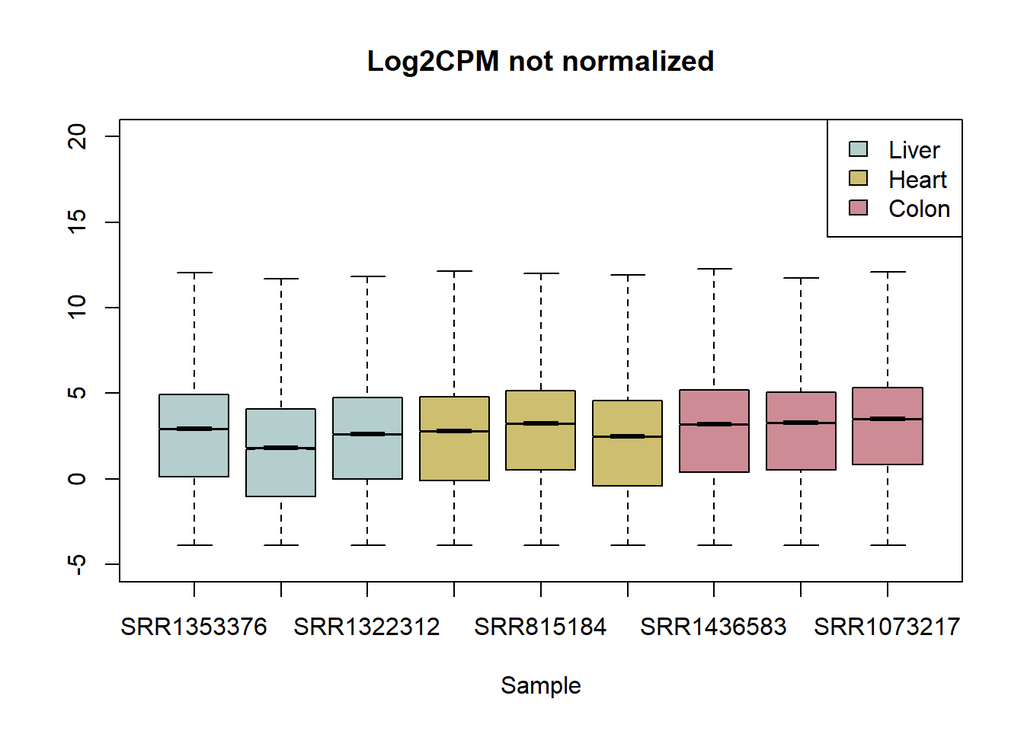

```r
# boxplot of the non-normalized counts
boxplot(logcpm_before, notch = TRUE, outline = FALSE, col = (c(rep("lightcyan3",
    3), rep("lightgoldenrod3", 3), rep("lightpink3", 3))), ylim = c(-5, 20), main = "Log2CPM not normalized",
    xlab = "Sample")
legend(x = "topright", legend = c("Liver", "Heart", "Colon"), fill = c("lightcyan3",
    "lightgoldenrod3", "lightpink3"))
```

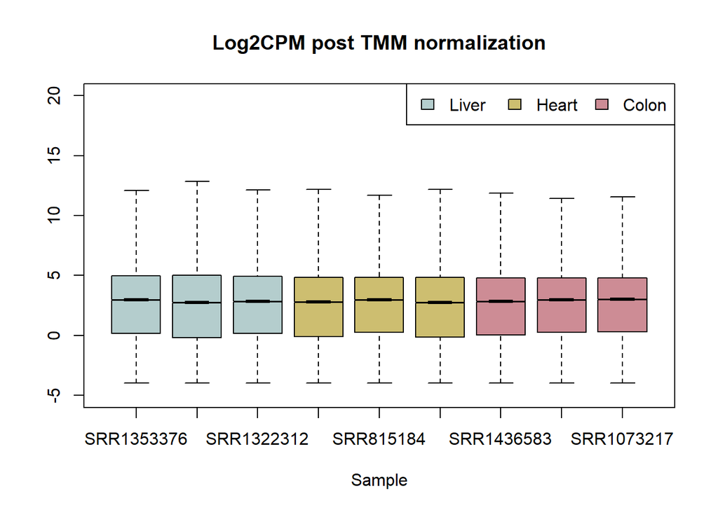

```r
# boxplot of the normalized counts
boxplot(logcpm, notch = TRUE, outline = FALSE, col = (c(rep("lightcyan3", 3), rep("lightgoldenrod3",
    3), rep("lightpink3", 3))), ylim = c(-5, 20), main = "Log2CPM post TMM normalization",
    xlab = "Sample")
legend(x = "topright", legend = c("Liver", "Heart", "Colon"), fill = c("lightcyan3",
    "lightgoldenrod3", "lightpink3"), ncol = 3)
```

By eyes we can see a change in the boxplot of the normalized counts if compared to the non_normalized, in fact after the normalization more of the samples are closer to the median horizontal line. Normalized the data we can start with the desgin model.

```r
# design the linear model
design <- model.matrix(~0 + group, data = y$samples)
# no intercept is used
colnames(design) <- levels(y$samples$group)
design
```

```
           colon heart liver
SRR1353376     0     0     1
SRR1499040     0     0     1
SRR1322312     0     0     1
SRR1468613     0     1     0
SRR815184      0     1     0
SRR1381693     0     1     0
SRR1436583     1     0     0
SRR1420413     1     0     0
SRR1073217     1     0     0
attr(,"assign")
[1] 1 1 1
attr(,"contrasts")
attr(,"contrasts")$group
[1] "contr.treatment"
```

## [VI] - Exploring data and analyzing them

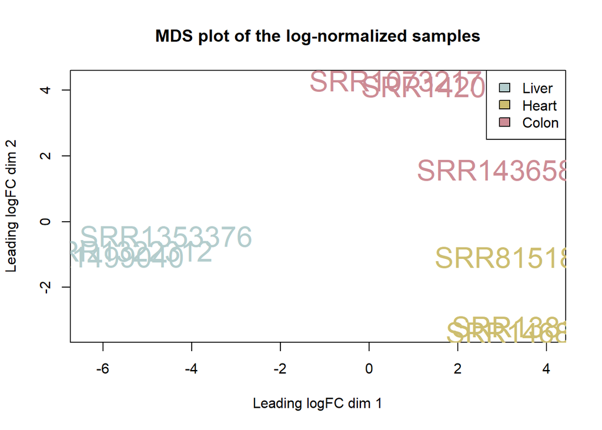

```r
# plot the samples labeled using MDS by tissue type
plotMDS(cpm(y, log = TRUE), labels = colnames(logcpm), col = c(rep("lightcyan3",
    3), rep("lightgoldenrod3", 3), rep("lightpink3", 3)), cex = 2)
legend("topright", legend = c("Liver", "Heart", "Colon"), fill = c("lightcyan3",
    "lightgoldenrod3", "lightpink3"))
title(main = "MDS plot of the log-normalized samples")
```

```r
# plot the samples labeled by gender
gender <- as.factor(c("male", "male", "male", "female", "male", "male", "female",
    "male", "male"))
y$samples$gender <- gender
y
```

```
An object of class "DGEList"
$counts
                   SRR1353376 SRR1499040 SRR1322312 SRR1468613 SRR815184
ENSG00000000003.14       1213       1375        850        179       412
ENSG00000000419.12        511        464        565        574       534
ENSG00000000457.13        459        294        304        263       334
ENSG00000000460.16        225        171        110        124       213
ENSG00000000938.12       1523        254        230        281       834
                   SRR1381693 SRR1436583 SRR1420413 SRR1073217
ENSG00000000003.14        133        371        507       3175
ENSG00000000419.12        490        790        906        793
ENSG00000000457.13        218        631        823        760
ENSG00000000460.16         99        334        430        380
ENSG00000000938.12        146         78        507        500
23781 more rows ...

$samples
           group lib.size norm.factors gender
SRR1353376 liver 27398974    0.9707927   male
SRR1499040 liver 31312957    0.5116174   male
SRR1322312 liver 21846141    0.8702407   male
SRR1468613 heart 24147086    0.9870639 female
SRR815184  heart 30551832    1.2157856   male
SRR1381693 heart 25852138    0.8363733   male
SRR1436583 colon 34109856    1.2970991 female
SRR1420413 colon 37682988    1.2331860   male
SRR1073217 colon 31119271    1.4410688   male
```

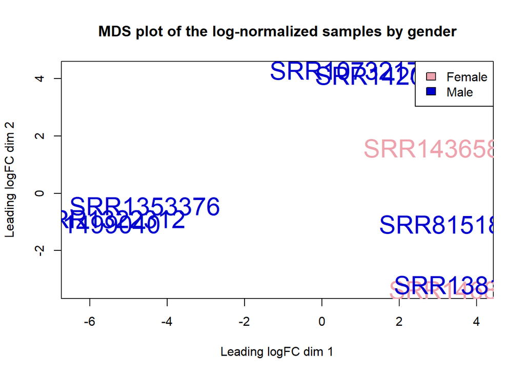

```r
plotMDS(cpm(y, log = TRUE), labels = colnames(logcpm), col = ifelse(y$samples$gender ==
    "female", "lightpink2", "mediumblue"), cex = 2)
legend("topright", legend = c("Female", "Male"), fill = c("lightpink2", "mediumblue"))
title(main = "MDS plot of the log-normalized samples by gender")
```

Observing the data, we investigate if the age 60-69 could be a biological factor or not.

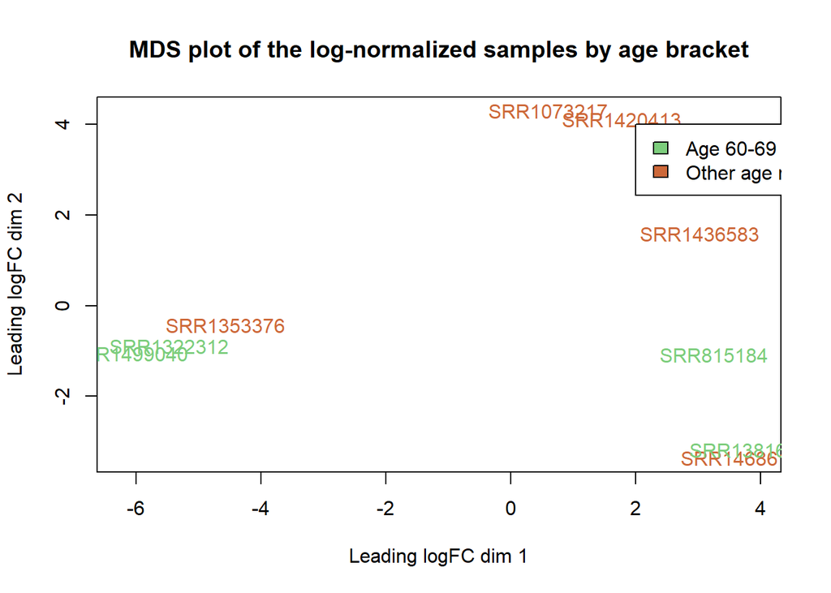

```r
# plot the samples labeled by age bracket
age <- as.factor(c("30-39", "60-69", "60-69", "20-29", "60-69", "60-69", "40-49",
    "40-49", "50-59"))
y$samples$age <- age
# y

plotMDS(cpm(y, log = TRUE), labels = colnames(logcpm), col = ifelse(y$samples$age ==
    "60-69", "palegreen3", "sienna3"))
legend(2, 4, legend = c("Age 60-69", "Other age ranges"), fill = c("palegreen3",
    "sienna3"))

title(main = "MDS plot of the log-normalized samples by age bracket")
```

```r
# Estimate BCV We estimate the negative binomial (NB) dispersions with
# estimateDisp()
y <- estimateDisp(y, design)
summary(y$trended.dispersion)
```

```
   Min. 1st Qu.  Median    Mean 3rd Qu.    Max.
 0.2653  0.2797  0.3690  0.3672  0.4462  0.5035
```

```r
# y$common.dispersion
```

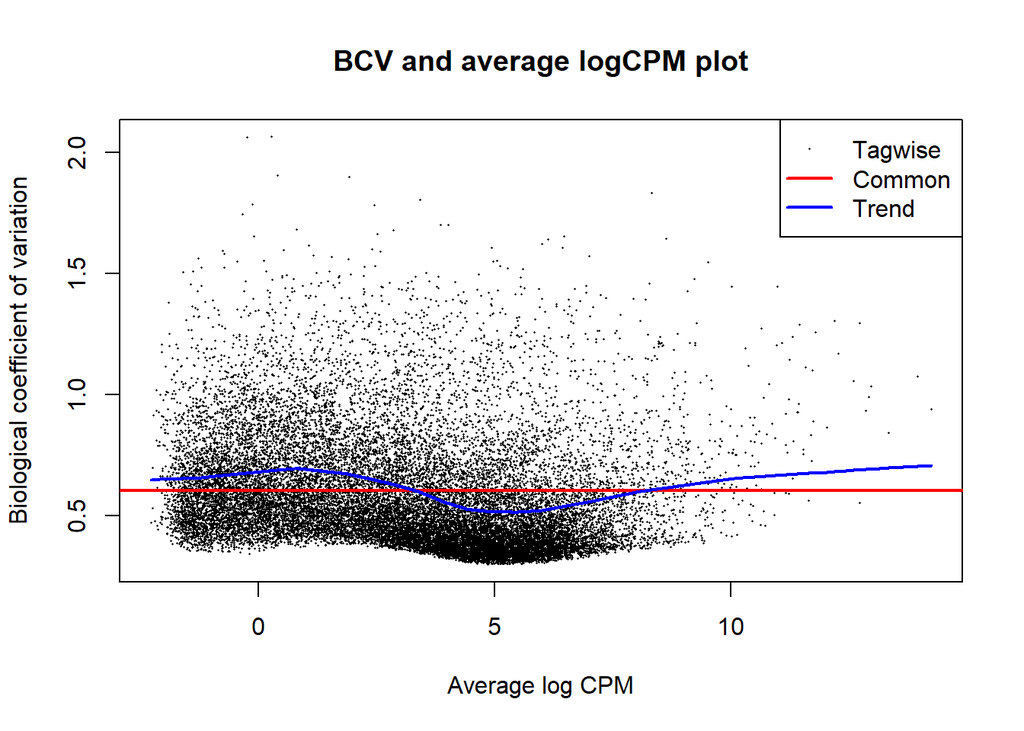

```r
plotBCV(y)
title(main = "BCV and average logCPM plot")
```

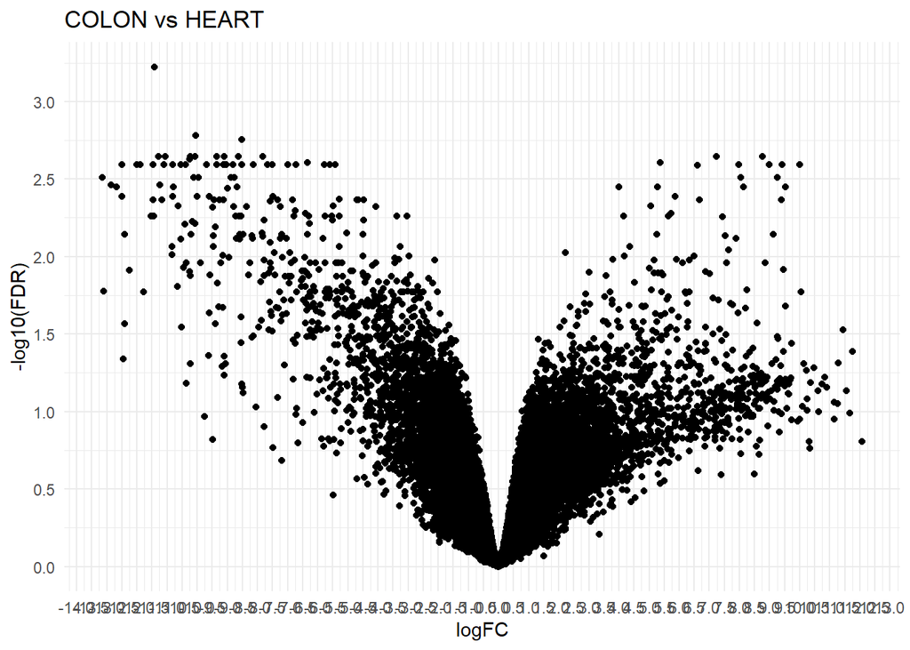

```r
# fit the data to the designed generalized linear model
fit <- glmQLFit(y, design)

# COLON VERSUS HEART 1vs2: colon versus heart
qlf.1vs2 <- glmQLFTest(fit, contrast = c(1, -1, 0))

# select the significant ones, with corrected p-value (FDR) < 0.05: colon
# versus colon
FDR.1vs2 <- p.adjust(qlf.1vs2$table$PValue, method = "BH")

# append the adjusted pvalue in the table
qlf.1vs2$table$FDR <- FDR.1vs2
# qlf.1vs2

# plot
p <- ggplot(data = qlf.1vs2$table, aes(x = logFC, y = -log10(FDR))) + geom_point() +
    theme_minimal() + scale_x_continuous(breaks = seq(-15, 15, 0.5)) + scale_y_continuous(breaks = seq(0,
    3.5, 0.5)) + ggtitle("COLON vs HEART")
p
```

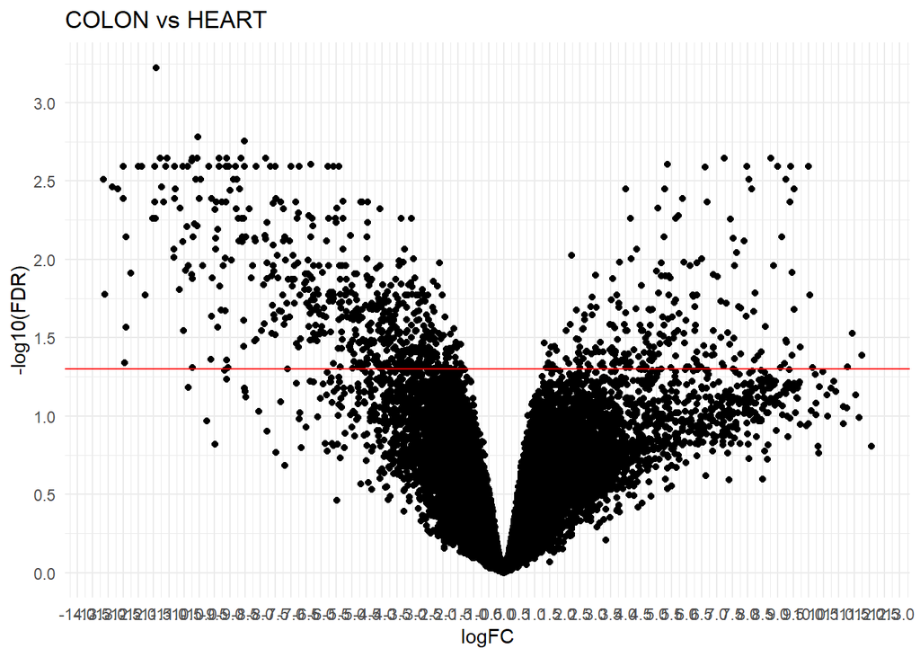

```r
p2 <- p + geom_hline(yintercept = -log10(0.05), col = "red")
p2
```

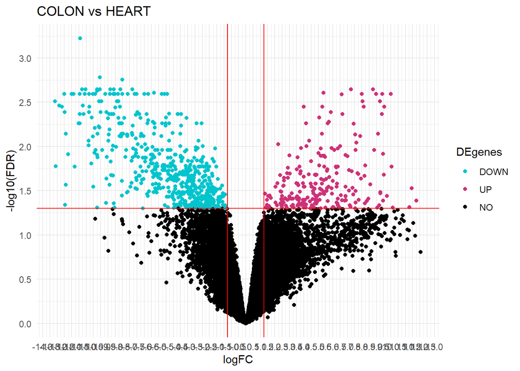

```r
# add a column of NAs
qlf.1vs2$table$DEgenes <- "NO"
# if log2Foldchange > 0 and pvalue < 0.05, set as 'UP'
qlf.1vs2$table$DEgenes[qlf.1vs2$table$logFC > 1 & qlf.1vs2$table$FDR < 0.05] <- "UP"
# if log2Foldchange < 0 and pvalue < 0.05, set as 'DOWN'
qlf.1vs2$table$DEgenes[qlf.1vs2$table$logFC < -1 & qlf.1vs2$table$FDR < 0.05] <- "DOWN"

# Re-plot but this time color the points with 'DEgenes'
p <- ggplot(data = qlf.1vs2$table, aes(x = logFC, y = -log10(FDR), col = DEgenes)) +
    scale_x_continuous(breaks = seq(-15, 15, 0.5)) + scale_y_continuous(breaks = seq(0,
    3.5, 0.5)) + geom_point() + theme_minimal() + ggtitle("COLON vs HEART")

# Add lines as before...
p2 <- p + geom_vline(xintercept = c(-1.25, 1.25), col = "red") + geom_hline(yintercept = -log10(0.05),
    col = "red")

mycolors <- c("turquoise3", "violetred3", "black")
names(mycolors) <- c("DOWN", "UP", "NO")
p3 <- p2 + scale_colour_manual(values = mycolors)
p3
```

```r
summary(decideTests(qlf.1vs2, p.value = 0.05))
```

```
       1*colon -1*heart
Down                573
NotSig            22980
Up                  233
```

```r
deg.1vs2 <- topTags(qlf.1vs2, n = 20000, adjust.method = "BH", sort.by = "PValue",
    p.value = 0.05)$table


up.genes.1vs2 <- row.names(deg.1vs2[deg.1vs2$logFC > 1, ])  #233
down.genes.1vs2 <- row.names(deg.1vs2[deg.1vs2$logFC < -1, ])  #573
# deg.1vs2
```

Usually, the transformation is log at base 2, so the interpretation is straightforward: a log(FC) of 1 means twice as expressed.

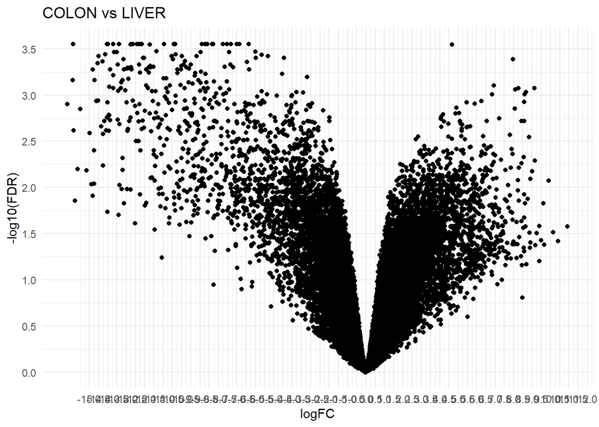

```r
# COLON vs LIVER
qlf.1vs3 <- glmQLFTest(fit, contrast = c(1, 0, -1))

# select the significant ones, with corrected p-value (FDR) < 0.05: heart
# versus colon
FDR.1vs3 <- p.adjust(qlf.1vs3$table$PValue, method = "BH")

# append the adjusted pvalue in the table
qlf.1vs3$table$FDR <- FDR.1vs3
# qlf.1vs3

# plot
p <- ggplot(data = qlf.1vs3$table, aes(x = logFC, y = -log10(FDR))) + geom_point() +
    theme_minimal() + scale_x_continuous(breaks = seq(-15, 15, 0.5)) + scale_y_continuous(breaks = seq(0,
    3.5, 0.5)) + ggtitle("COLON vs LIVER")
p
```

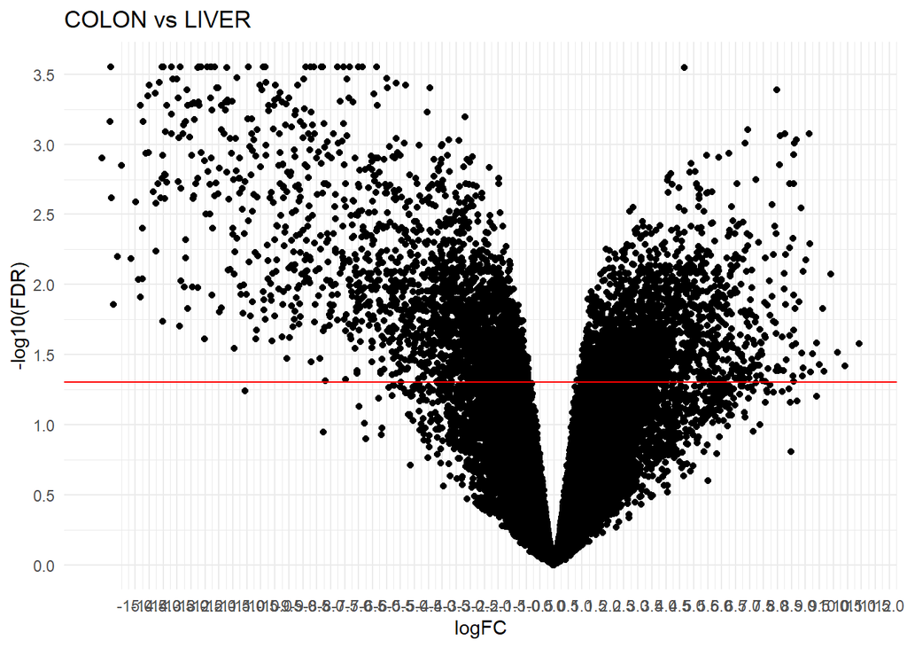

```r
p2 <- p + geom_hline(yintercept = -log10(0.05), col = "red")
p2
```

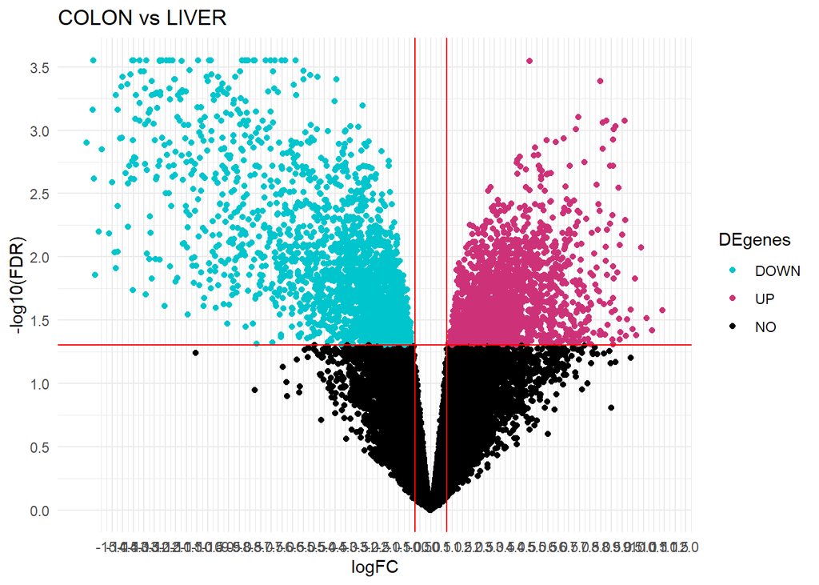

```r
# add a column of NAs
qlf.1vs3$table$DEgenes <- "NO"
# if log2Foldchange > 0 and pvalue < 0.05, set as 'UP'
qlf.1vs3$table$DEgenes[qlf.1vs3$table$logFC > 0.75 & qlf.1vs3$table$FDR < 0.05] <- "UP"
# if log2Foldchange < 0 and pvalue < 0.05, set as 'DOWN'
qlf.1vs3$table$DEgenes[qlf.1vs3$table$logFC < -0.75 & qlf.1vs3$table$FDR < 0.05] <- "DOWN"

# Re-plot but this time color the points with 'DEgenes'
p <- ggplot(data = qlf.1vs3$table, aes(x = logFC, y = -log10(FDR), col = DEgenes)) +
    scale_x_continuous(breaks = seq(-15, 15, 0.5)) + scale_y_continuous(breaks = seq(0,
    3.5, 0.5)) + geom_point() + theme_minimal() + ggtitle("COLON vs LIVER")

# Add lines as before...
p2 <- p + geom_vline(xintercept = c(-0.75, 0.75), col = "red") + geom_hline(yintercept = -log10(0.05),
    col = "red")

mycolors <- c("turquoise3", "violetred3", "black")
names(mycolors) <- c("DOWN", "UP", "NO")
p3 <- p2 + scale_colour_manual(values = mycolors)
p3
```

```r
summary(decideTests(qlf.1vs3, p.value = 0.05))
```

```
       1*colon -1*liver
Down               2223
NotSig            19590
Up                 1973
```

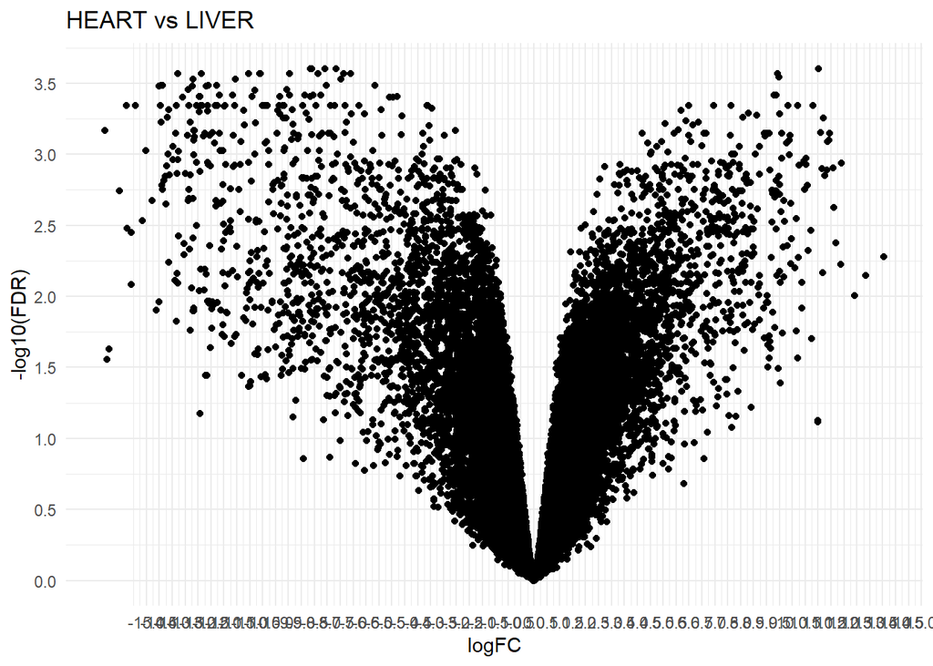

```r
deg.1vs3 <- topTags(qlf.1vs3, n = 20000, adjust.method = "BH", sort.by = "PValue",
    p.value = 0.05)$table
up.genes.1vs3 <- row.names(deg.1vs3[deg.1vs3$logFC > 1, ])  #1967
down.genes.1vs3 <- row.names(deg.1vs3[deg.1vs3$logFC < -1, ])  #2210
# deg.1vs3

# HEART vs LIVER
qlf.2vs3 <- glmQLFTest(fit, contrast = c(0, 1, -1))
FDR.2vs3 <- p.adjust(qlf.2vs3$table$PValue, method = "BH")

# append the adjusted pvalue in the table
qlf.2vs3$table$FDR <- FDR.2vs3
# qlf.2vs3

# plot
p <- ggplot(data = qlf.2vs3$table, aes(x = logFC, y = -log10(FDR))) + geom_point() +
    theme_minimal() + scale_x_continuous(breaks = seq(-15, 15, 0.5)) + scale_y_continuous(breaks = seq(0,
    3.5, 0.5)) + ggtitle("HEART vs LIVER")
p
```

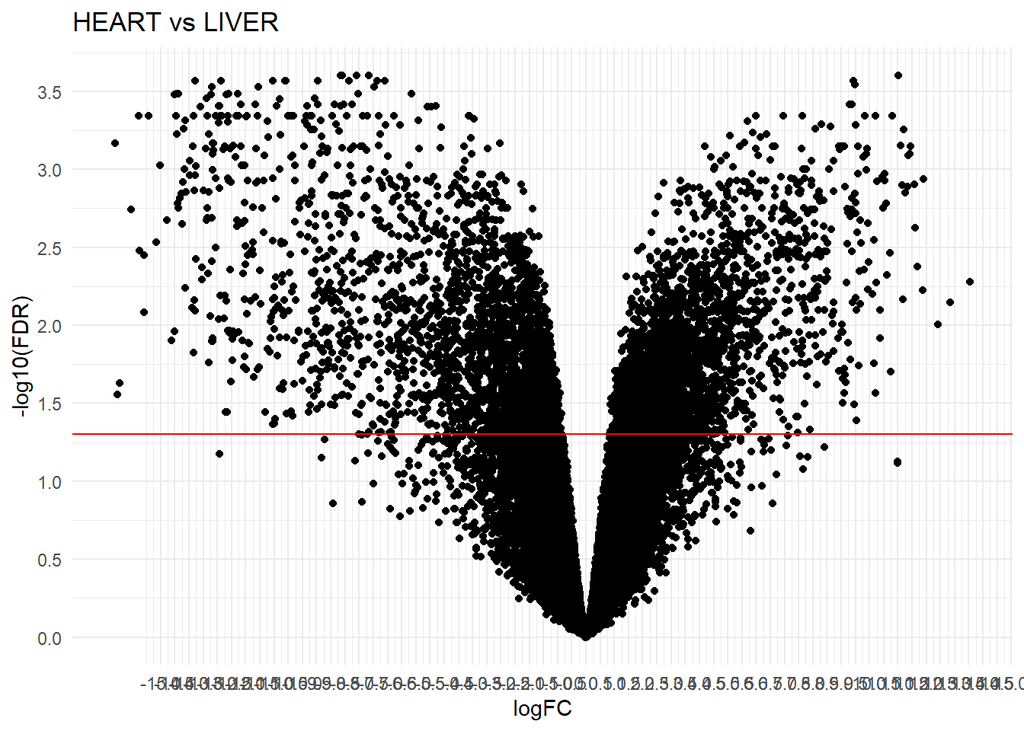

```r
p2 <- p + geom_hline(yintercept = -log10(0.05), col = "red")
p2
```

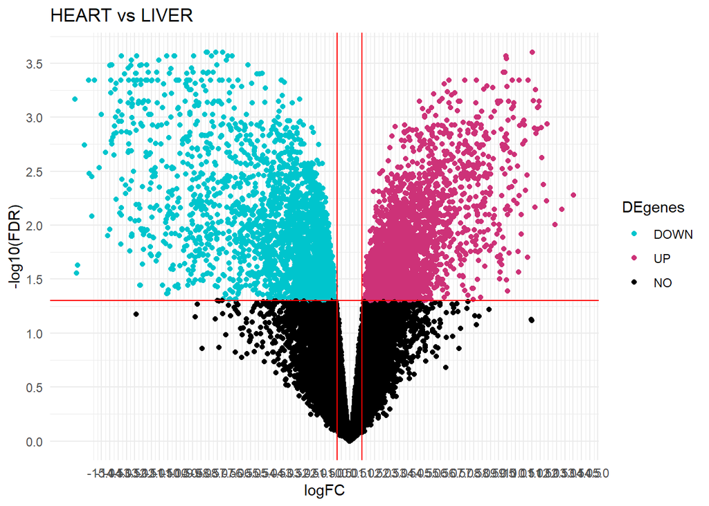

```r
# add a column of NAs
qlf.2vs3$table$DEgenes <- "NO"
# if log2Foldchange > 0 and pvalue < 0.05, set as 'UP'
qlf.2vs3$table$DEgenes[qlf.2vs3$table$logFC > 0.75 & qlf.2vs3$table$FDR < 0.05] <- "UP"
# if log2Foldchange < 0 and pvalue < 0.05, set as 'DOWN'
qlf.2vs3$table$DEgenes[qlf.2vs3$table$logFC < -0.75 & qlf.2vs3$table$FDR < 0.05] <- "DOWN"

# Re-plot but this time color the points with 'DEgenes'
p <- ggplot(data = qlf.2vs3$table, aes(x = logFC, y = -log10(FDR), col = DEgenes)) +
    scale_x_continuous(breaks = seq(-15, 15, 0.5)) + scale_y_continuous(breaks = seq(0,
    3.5, 0.5)) + geom_point() + theme_minimal() + ggtitle("HEART vs LIVER")

# Add lines as before...
p2 <- p + geom_vline(xintercept = c(-0.75, 0.75), col = "red") + geom_hline(yintercept = -log10(0.05),
    col = "red")

mycolors <- c("turquoise3", "violetred3", "black")
names(mycolors) <- c("DOWN", "UP", "NO")
p3 <- p2 + scale_colour_manual(values = mycolors)
p3
```

```r
summary(decideTests(qlf.2vs3, p.value = 0.05))
```

```
       1*heart -1*liver
Down               2688
NotSig            18580
Up                 2518
```

```r
deg.2vs3 <- topTags(qlf.2vs3, n = 20000, adjust.method = "BH", sort.by = "PValue",
    p.value = 0.05)$table
up.genes.2vs3 <- row.names(deg.2vs3[deg.2vs3$logFC > 1, ])  #2501
down.genes.2vs3 <- row.names(deg.2vs3[deg.2vs3$logFC < -1, ])  #2654
# deg.2vs3
```

And now I’m going to find the up and down regulated genes of my dataset

```r
# Colon
up.colon <- intersect(up.genes.1vs2, up.genes.1vs3)
down.colon <- intersect(down.genes.1vs2, down.genes.1vs3)

# Heart
up.heart <- intersect(up.genes.2vs3, down.genes.1vs2)
down.heart <- intersect(down.genes.2vs3, up.genes.1vs2)

# Liver
up.liver <- intersect(down.genes.1vs3, down.genes.2vs3)
down.liver <- intersect(up.genes.1vs3, up.genes.2vs3)
```

## [VII] - Prepare the file for the export to Excel

The following code was founded in GitHub taken from the Daniele Colombo’s vignette.

```r
de.genes.dataframe <- function(col1, col2, column.names) {
    de.genes <- data.frame(col1 = rep(NA, max(sapply(list(col1, col2), length))))
    de.genes[1:length(col1), 1] <- col1
    de.genes[1:length(col2), 2] <- col2
    colnames(de.genes) <- column.names

    return(de.genes)
}
```

```r
comparison.1vs2 <- de.genes.dataframe(up.genes.1vs2, down.genes.1vs2, c("up.colon.vs.heart",
    "down.colon.vs.heart"))
comparison.1vs3 <- de.genes.dataframe(up.genes.1vs3, down.genes.1vs3, c("up.colon.vs.liver",
    "down.colon.vs.liver"))
comparison.2vs3 <- de.genes.dataframe(up.genes.2vs3, down.genes.2vs3, c("up.heart.vs.liver",
    "down.heart.vs.liver"))

de.genes.colon <- de.genes.dataframe(up.colon, down.colon, c("up.colon", "down.colon"))
de.genes.heart <- de.genes.dataframe(up.heart, down.heart, c("up.heart", "down.heart"))
de.genes.liver <- de.genes.dataframe(up.liver, down.liver, c("up.liver", "down.liver"))
```

Obtaining the xls files of the DE gene list

```r
write.xlsx(comparison.1vs2, "DE_genes.xlsx", sheetName = "Tissue 1 vs 2", col.names = TRUE,
    row.names = FALSE, append = FALSE, showNA = FALSE)
write.xlsx(comparison.1vs3, "DE_genes.xlsx", sheetName = "Tissue 1 vs 3", col.names = TRUE,
    row.names = FALSE, append = TRUE, showNA = FALSE)
write.xlsx(comparison.2vs3, "DE_genes.xlsx", sheetName = "Tissue 2 vs 3", col.names = TRUE,
    row.names = FALSE, append = TRUE, showNA = FALSE)
write.xlsx(de.genes.colon, "DE_genes.xlsx", sheetName = "DE genes tissue 1", col.names = TRUE,
    row.names = FALSE, append = TRUE, showNA = FALSE)
write.xlsx(de.genes.heart, "DE_genes.xlsx", sheetName = "DE genes tissue 2", col.names = TRUE,
    row.names = FALSE, append = TRUE, showNA = FALSE)
write.xlsx(de.genes.liver, "DE_genes.xlsx", sheetName = "DE genes tissue 3", col.names = TRUE,
    row.names = FALSE, append = TRUE, showNA = FALSE)
```

For the functional enrichment analysis we needed to retrieve the list of gene_symbols using Enrichr, so:

```r
# functional enrichment analysis
write.gene.symbols <- function(ensembl, file.name) {
    symbols <- mapIds(org.Hs.eg.db, keys = gsub("\\..*", "", ensembl), keytype = "ENSEMBL",
        column = "SYMBOL", multiVals = "first")
    write.table(symbols[!is.na(symbols)], file.name, col.names = F, row.names = F,
        quote = F)
}

write.gene.symbols(up.colon, "up_colon_symbols.txt")
write.gene.symbols(up.heart, "up_heart_symbols.txt")
write.gene.symbols(up.liver, "up_liver_symbols.txt")
```

```r
up_1vs2_FDR <- data.frame(deg.1vs2[deg.1vs2$logFC > 0, ]$FDR)
up_1vs2_FDR$ENSG <- row.names(deg.1vs2[deg.1vs2$logFC > 0, ])
row.names(up_1vs2_FDR) <- up_1vs2_FDR$ENSG

up_1vs3_FDR <- data.frame(deg.1vs3[deg.1vs3$logFC > 0, ]$FDR)
up_1vs3_FDR$ENSG <- row.names(deg.1vs3[deg.1vs3$logFC > 0, ])
row.names(up_1vs3_FDR) <- up_1vs3_FDR$ENSG

up_both <- merge(up_1vs2_FDR, up_1vs3_FDR)
sort_up_both <- up_both[order(up_both$deg.1vs2.deg.1vs2.logFC...0....FDR, up_both$deg.1vs3.deg.1vs3.logFC...0....FDR),
    ]
```